# Análisis LAPOP - Formalidad/Informalidad

Tomás J. Gianibelli

Enero, 2021

Prendo las librerías necesarias

```r
library(tidyverse)
library(haven)
library(ggthemes)
library(patchwork)
```

# Importando, limpiando y transformando datos

Guardo como objeto los .dta correspondientes a los 4 países seleccionados para realizar el trabajo (Argentina, Brasil, Chile y Uruguay)

```r
Argentina <- read_dta('~/Desktop/DATA/LAPOP Argentina.dta')
Brasil <- read_dta('~/Desktop/DATA/LAPOP Brasil.dta')
Chile <- read_dta('~/Desktop/DATA/LAPOP Chile.dta')
Uruguay <- read_dta('~/Desktop/DATA/LAPOP Uruguay.dta')
```

Limpio los 4 dataframes de las variables que no voy a utilizar y los guardo nuevamente como objetos

```r
Argentinac <- select(Argentina, uniq_id, formal, pais, a4, l1, prot3, b21, ros4, redist1, redist2a, redist3, pn4, vb10, pol1)
Brasilc <- select(Brasil, uniq_id, formal, pais, a4, l1, prot3, b21, ros4, redist1, redist2a, redist3, pn4, vb10, pol1)
Chilec <- select(Chile, uniq_id, formal, pais, a4, l1, prot3, b21, ros4, redist1, redist2a, redist3, pn4, vb10, pol1)
Uruguayc <- select(Uruguay, uniq_id, formal, pais, a4, l1, prot3, b21, ros4, redist1, redist2a, redist3, pn4, vb10, pol1)
```

Unifico verticalmente los 4 dataframes en un solo objeto y limpiamos el *environment*

```r
Base <- bind_rows(Argentinac, Brasilc, Chilec, Uruguayc)
rm(Argentina, Argentinac, Brasil, Brasilc, Chile, Chilec, Uruguay, Uruguayc)
```

Ante todo, a la hora de trasnformar las variables de nuestro dataset, vamos a elminar las observaciones que no posean valor en la variable *formal*. Esto resulta necesario dado que nuestro objetivo general va a ser observar las diferencias en las preferencias de trabajadores formales e informales.

```r
Base <- drop_na(Base, formal)
```

Posteriormente, vamos a generar dos variables categóricas que nos permitan realizar una correcta visualización de la distribución de preferencias de los encuestados de acuerdo a su nacionalidad y relación laboral. Además cambio valores de otras variables para que sean más informativas.

```r
Base <- Base %>%
  mutate(Nacionalidad = case_when(pais == 17 ~ 'Argentina',
                                  pais == 14 ~ 'Uruguay',
                                  pais == 15 ~ 'Brasil',
                                  pais == 13 ~ 'Chile'))


Base <- Base %>%
  mutate(Formalidad = case_when(formal == 1 ~ 'Formal',
                                formal == 2 ~ 'Informal'))

Base <- Base %>%
  mutate(Protesta = case_when(prot3 == 1 ~ 'Participó',
                              prot3 == 2 ~ 'No participó'))

Base <- Base %>%
  mutate(Simpatía = case_when(vb10 == 1 ~ 'Si',
                              vb10 == 2 ~ 'No'))

Base <- Base %>%
  mutate(Interés = case_when(pol1 == 1 ~ 'Mucho',
                             pol1 == 2 ~ 'Algo',
                             pol1 == 3 ~ 'Poco',
                             pol1 == 4 ~ 'Nada'))

Base <- Base %>%
  mutate(Problemas = case_when(a4 == 1 ~ 'Economía',
                               a4 == 2 ~ 'Inflación',
                               a4 == 3 ~ 'Desempleo',
                               a4 == 4 ~ 'Pobreza',
                               a4 == 5 ~ 'Delincuencia',
                               a4 == 6 ~ 'Protestas populares',
                               a4 == 7 ~ 'Falta de tierra',
                               a4 == 9 ~ 'Falta de crédito',
                               a4 == 10 ~ 'Medio ambiente',
                               a4 == 11 ~ 'Drogadicción',
                               a4 == 12 ~ 'Narcotráfico',
                               a4 == 13 ~ 'Corrupción',
                               a4 == 14 ~ 'Pandillas',
                               a4 == 15 ~ 'Mal gobierno',
                               a4 == 16 ~ 'Migración',
                               a4 == 18 ~ 'Malos caminos',
                               a4 == 19 ~ 'Falta de agua',
                               a4 == 20 ~ 'Explosión demográfica',
                               a4 == 21 ~ 'Calidad educativa',
                               a4 == 22 ~ 'Calidad sanitaria',
                               a4 == 24 ~ 'Falta de electricidad',
                               a4 == 25 ~ 'Discriminación',
                               a4 == 26 ~ 'Deuda externa',
                               a4 == 27 ~ 'Falta de seguridad',
                               a4 == 30 ~ 'Conflicto armado',
                               a4 == 31 ~ 'Secuestro',
                               a4 == 32 ~ 'Desplazamiento forzado',
                               a4 == 33 ~ 'Terrorismo',
                               a4 == 55 ~ 'Vivienda',
                               a4 == 56 ~ 'Derechos humanos',
                               a4 == 57 ~ 'Violencia',
                               a4 == 58 ~ 'Desigualdad',
                               a4 == 59 ~ 'Los políticos',
                               a4 == 60 ~ 'Servicio transporte',
                               a4 == 61 ~ 'Impunidad',
                               a4 == 70 ~ 'Otro',
                               a4 == 80 ~ 'Violencia contra mujer'))
```

# Gráficos

Realizamos una serie de gráficos multi-panel que permitan observar la distribución de peferencias de acuerdo a status laboral y nacionalidad de los encuestados. Para ello vamos a usar en general *ggplot2* y en específico la función de *facetwrap*.

Comenzamos observando la distribución de preferencias izquierda/derecha

[figure not shown]

```r
Basecount <- count(Base, l1, Formalidad, Nacionalidad)

ggplot(data = subset(Basecount, !is.na(l1)), aes(l1, n)) +
  geom_col() +
  facet_wrap(~ Formalidad) +
  labs(x = 'Ideología Política Autopercibida',
       y = 'N',
       caption = 'LAPOP') +
  theme_minimal() +
  theme(text = element_text('Avenir Next Condensed'),
        plot.caption = element_text(face = 'italic')) +
  scale_x_continuous(breaks = c(1, 2, 3, 4, 5, 6, 7, 8, 9, 10),
                   labels = c('Izquierda', '2', '3', '4', '5', '6', '7', '8', '9', 'Derecha'))
```

[figure not shown]

```r
ggplot(Basecount, aes(l1, n)) +
  geom_col() +
  facet_wrap(~ Nacionalidad + Formalidad) +
  labs(x = 'Ideología Política Autopercibida',
       y = 'N',
       caption = 'LAPOP') +
  theme_minimal() +
  theme(text = element_text('Avenir Next Condensed'),
        plot.caption = element_text(face = 'italic')) +
    scale_x_continuous(breaks = c(1, 2, 3, 4, 5, 6, 7, 8, 9, 10),
                   labels = c('I', '2', '3', '4', '5', '6', '7', '8', '9', 'D'))
```

Observamos la distribución de encuestados que participaron en protestas en los últimos 12 meses. En este caso tenemos que agregar la función *subset* para poder eliminar las observaciones con valor *NA* en la variable *Protesta* de nuestro gráfico.

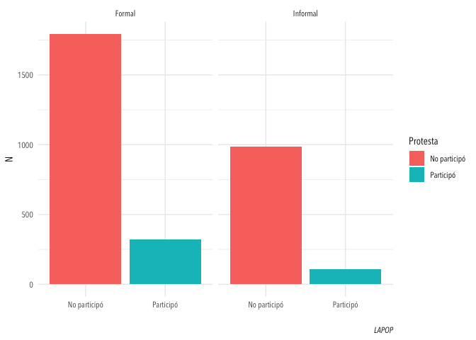

```r
Basecount <- count(Base, Protesta, Formalidad, Nacionalidad)

ggplot(data = subset(Basecount, !is.na(Protesta)), aes(Protesta, n, fill = Protesta)) +
  geom_col() +
  facet_wrap(~ Formalidad) +
  labs(y = 'N',
       x = '',
       caption = 'LAPOP') +
  theme_minimal() +
  theme(text = element_text('Avenir Next Condensed'),
        plot.caption = element_text(face = 'italic'))
```

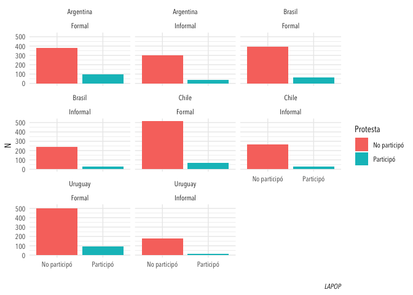

```r
ggplot(data = subset(Basecount, !is.na(Protesta)), aes(Protesta, n, fill = Protesta)) +
  geom_col() +
  facet_wrap(~ Nacionalidad + Formalidad) +
  labs(y = 'N',
       x = '',
       caption = 'LAPOP') +
  theme_minimal() +
  theme(text = element_text('Avenir Next Condensed'),
        plot.caption = element_text(face = 'italic'))
```

Observamos apoyos a políticas que permitan reducir la desigualdad.

[figure not shown]

```r
# Medidas que reduzcan desigualdad ricos/pobres

Basecount <- count(Base, ros4, Formalidad, Nacionalidad)

ggplot(Basecount, aes(ros4, n)) +
  geom_col() +
  facet_wrap(~ Formalidad) +
  labs(x = '',
       y = 'N',
       caption = 'LAPOP') +
  theme_minimal() +
  theme(text = element_text('Avenir Next Condensed'),
        plot.caption = element_text(face = 'italic')) +
  scale_x_continuous(breaks = c(1:7),
                     labels = c('En contra', '2', '3', '4', '5', '6', 'A favor'))
```

[figure not shown]

```r
ggplot(Basecount, aes(ros4, n)) +
  geom_col() +
  facet_wrap(~ Nacionalidad + Formalidad) +
  labs(x = '',
       y = 'N',
       caption = 'LAPOP') +
  theme_minimal() +
  theme(text = element_text('Avenir Next Condensed'),
        plot.caption = element_text(face = 'italic')) +
  scale_x_continuous(breaks = c(1:7),
                     labels = c('En contra', '2', '3', '4', '5', '6', 'A favor'))
```

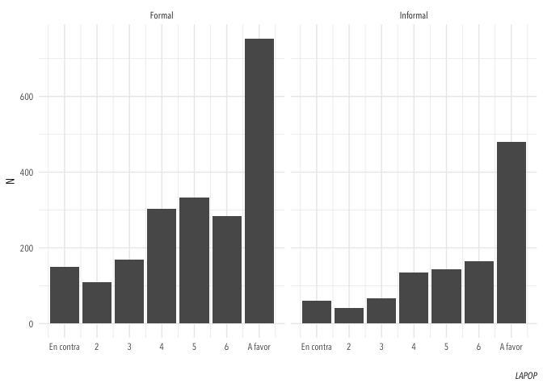

```r
# Medidas de asistencia a pobres

Basecount <- count(Base, redist1, Formalidad, Nacionalidad)

ggplot(Basecount, aes(redist1, n)) +
  geom_col() +
  facet_wrap(~ Formalidad) +
  labs(x = '',
       y = 'N',
       caption = 'LAPOP') +
  theme_minimal() +
  theme(text = element_text('Avenir Next Condensed'),
        plot.caption = element_text(face = 'italic')) +
  scale_x_continuous(breaks = c(1:7),
                     labels = c('En contra', '2', '3', '4', '5', '6', 'A favor'))
```

[figure not shown]

```r
ggplot(Basecount, aes(redist1, n)) +
  geom_col() +
  facet_wrap(~ Nacionalidad + Formalidad) +
  labs(x = '',
       y = 'N',
       caption = 'LAPOP') +
  theme_minimal() +
  theme(text = element_text('Avenir Next Condensed'),
        plot.caption = element_text(face = 'italic')) +
  scale_x_continuous(breaks = c(1:7),
                     labels = c('En contra', '2', '3', '4', '5', '6', 'A favor'))
```

[figure not shown]

```r
# Ricos pagan muchos impuestos pero reciben pocos servicios

Basecount <- count(Base, redist2a, Formalidad, Nacionalidad)

ggplot(Basecount, aes(redist2a, n)) +
  geom_col() +
  facet_wrap(~ Formalidad) +
  labs(x = '',
       y = 'N',
       caption = 'LAPOP') +
  theme_minimal() +
  theme(text = element_text('Avenir Next Condensed'),
        plot.caption = element_text(face = 'italic')) +
  scale_x_continuous(breaks = c(1:7),
                     labels = c('En contra', '2', '3', '4', '5', '6', 'A favor'))
```

[figure not shown]

```r
ggplot(Basecount, aes(redist2a, n)) +
  geom_col() +
  facet_wrap(~ Nacionalidad + Formalidad) +
  labs(x = '',
       y = 'N',
       caption = 'LAPOP') +
  theme_minimal() +
  theme(text = element_text('Avenir Next Condensed'),
        plot.caption = element_text(face = 'italic')) +
  scale_x_continuous(breaks = c(1:7),
                     labels = c('En contra', '2', '3', '4', '5', '6', 'A favor'))
```

[figure not shown]

```r
# La mayoría de los desempleados podría encontrar empleo si quisiera

Basecount <- count(Base, redist3, Formalidad, Nacionalidad)

ggplot(Basecount, aes(redist3, n)) +
  geom_col() +
  facet_wrap(~ Formalidad) +
  labs(x = '¿Está de acuerdo con que la mayoría de los desempleados podría encontrar empleo si quisiera?',
       y = 'N',
       caption = 'LAPOP') +
  theme_minimal() +
  theme(text = element_text('Avenir Next Condensed'),
        plot.caption = element_text(face = 'italic')) +
  scale_x_continuous(breaks = c(1:7),
                     labels = c('En contra', '2', '3', '4', '5', '6', 'A favor'))
```

[figure not shown]

```r
ggplot(Basecount, aes(redist3, n)) +
  geom_col() +
  facet_wrap(~ Nacionalidad + Formalidad) +
  labs(x = '¿Está de acuerdo con que la mayoría de los desempleados podría encontrar empleo si quisiera?',
       y = 'N',
       caption = 'LAPOP') +
  theme_minimal() +
  theme(text = element_text('Avenir Next Condensed'),
        plot.caption = element_text(face = 'italic')) +
    scale_x_continuous(breaks = c(1:7),
                     labels = c('En contra', '2', '3', '4', '5', '6', 'A favor'))
```

Indagamos en posibles diferencias que puedan llegar a existir en términos de participación política

[figure not shown]

```r
# Confianza en partidos políticos

Basecount <- count(Base, b21, Formalidad, Nacionalidad)

ggplot(Basecount, aes(b21, n)) +
  geom_col() +
  facet_wrap(~ Formalidad) +
  labs(x = 'Confianza en los partidos políticos',
       y = 'N',
       caption = 'LAPOP') +
  theme_minimal() +
  theme(text = element_text('Avenir Next Condensed'),
        plot.caption = element_text(face = 'italic')) +
  scale_x_continuous(breaks = c(1:7),
                     labels = c('Nada', '2', '3', '4', '5', '6', 'Mucho'))
```

[figure not shown]

```r
ggplot(Basecount, aes(b21, n)) +
  geom_col() +
  facet_wrap(~ Nacionalidad + Formalidad) +
  labs(x = 'Confianza en los partidos políticos',
       y = 'N',
       caption = 'LAPOP') +
  theme_minimal() +
  theme(text = element_text('Avenir Next Condensed'),
        plot.caption = element_text(face = 'italic')) +
    scale_x_continuous(breaks = c(1:7),
                     labels = c('Nada', '2', '3', '4', '5', '6', 'Mucho'))
```

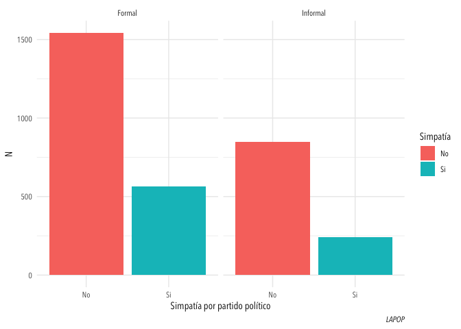

```r
# Simpatía con partido político

Basecount <- count(Base, Simpatía, Formalidad, Nacionalidad)

ggplot(data = subset(Basecount, !is.na(Simpatía)), aes(Simpatía, n, fill = Simpatía)) +
  geom_col() +
  facet_wrap(~ Formalidad) +
  labs(x = 'Simpatía por partido político',
       y = 'N',
       caption = 'LAPOP') +
  theme_minimal() +
  theme(text = element_text('Avenir Next Condensed'),
        plot.caption = element_text(face = 'italic'))
```

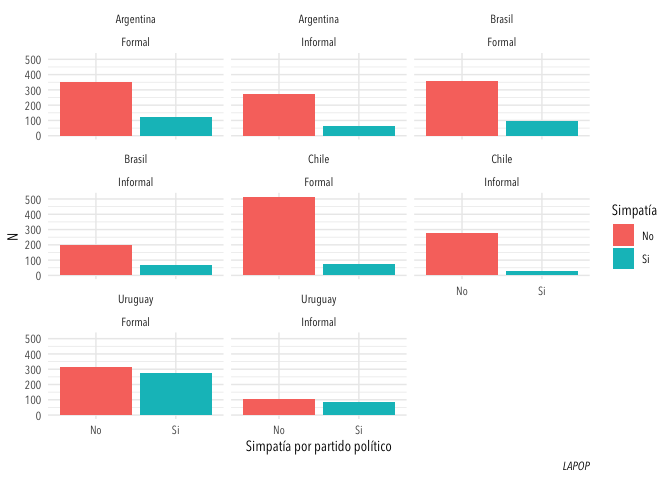

```r
ggplot(data = subset(Basecount, !is.na(Simpatía)), aes(Simpatía, n, fill = Simpatía)) +
  geom_col() +
  facet_wrap(~ Nacionalidad + Formalidad) +
  labs(x = 'Simpatía por partido político',
       y = 'N',
       caption = 'LAPOP') +
  theme_minimal() +
  theme(text = element_text('Avenir Next Condensed'),
        plot.caption = element_text(face = 'italic'))
```

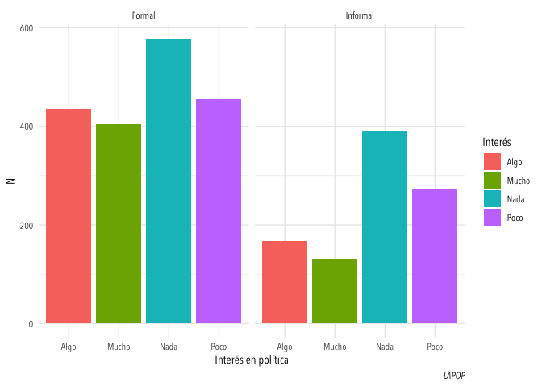

```r
# Interés en política

Basecount <- count(Base, Interés, Formalidad, Nacionalidad)

ggplot(data = subset(Basecount, !is.na(Interés)), aes(Interés, n, fill = Interés)) +
  geom_col() +
  facet_wrap(~ Formalidad) +
  labs(x = 'Interés en política',
       y = 'N',
       caption = 'LAPOP') +
  theme_minimal() +
  theme(text = element_text('Avenir Next Condensed'),
        plot.caption = element_text(face = 'italic'))
```

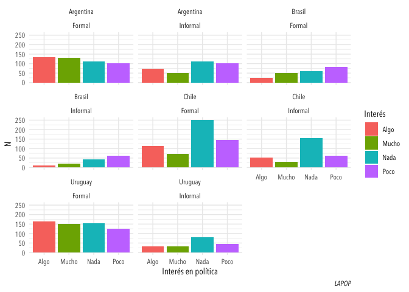

```r
ggplot(data = subset(Basecount, !is.na(Interés)), aes(Interés, n, fill = Interés)) +
  geom_col() +
  facet_wrap(~ Nacionalidad + Formalidad) +
  labs(x = 'Interés en política',
       y = 'N',
       caption = 'LAPOP') +
  theme_minimal() +
  theme(text = element_text('Avenir Next Condensed'),
        plot.caption = element_text(face = 'italic'))
```

Finalmente, analizamos el tipo de problemas que los encuestados encuentran más relevantes en su vida diaria. Para ello vamos a tener que realizar una serie de modificaciones a nuestra base de datos. En primer lugar, dado que la variable que deseamos analizar ( *a4* ) cuenta con una cantidad de categorías en exceso elevada, y nuestro interés es enfocarnos en los problemas con mayor cantidad de menciones, debemos reducir la cantidad de categorías que vamos a reproducir en nuestros graficos. Para ello, debemos realizar una serie de recortes en nuestro *dataframe* no sólo en términos de cantidad de observaciones en las categorías de nuestra variable ( *a4* ) sino también siguiendo los distintos valores que pueden tener nuestras observaciones en términos de status laboral y nacionalidad. En segundo lugar, y dado que *ggplot2* ordena el eje x por default en términos alfabéticos, debemos alterar explicitamente el orden de los *factor levels* para que el gráfico aparezca ordenado siguiendo un criterio numérico (cantida de observaciones). Finalmente, haciendo uso de *patchwork* realizamos una serie de gráficos combinados que nos permiten observar la distribución de preferencias siguiendo las líneas de status laboral y en cada país en específico.

[figure not shown]

```r
# Formales - General

Basef <- subset(Base, Base$Formalidad == 'Formal')

a <- Basef %>%
  group_by(Problemas) %>%
  count() %>%
  arrange(desc(n)) %>%
  filter(n >= 150)

a$Problemas <- factor(a$Problemas, levels = a$Problemas[order(a$n)])


Formales <- ggplot(a) +
  geom_bar(aes(x = Problemas, y = n, fill = Problemas), stat = 'identity') +
  labs(title = 'Formales',
       x = '',
       y = 'N') +
  theme_minimal() +
  theme(text = element_text('Avenir Next Condensed'),
        plot.title = element_text(hjust = 0.5),
        axis.text.x = element_text(angle = 45,
                                   hjust = 1),
        legend.position = 'none')

# Informales - General

Basef <- subset(Base, Base$Formalidad == 'Informal')

a <- Basef %>%
  group_by(Problemas) %>%
  count() %>%
  arrange(desc(n)) %>%
  filter(n >= 75)

a$Problemas <- factor(a$Problemas, levels = a$Problemas[order(a$n)])


Informales <- ggplot(a) +
  geom_bar(aes(x = Problemas, y = n, fill = Problemas), stat = 'identity') +
  labs(title = 'Informales',
       x = '',
       y = 'N') +
  theme_minimal() +
  theme(text = element_text('Avenir Next Condensed'),
        plot.title = element_text(hjust = 0.5),
        axis.text.x = element_text(angle = 45,
                                   hjust = 1),
        legend.position = 'none')

# Gráfico conjunto - General

Formales + Informales +
  plot_annotation(title = '',
                  caption = 'LAPOP',
                  theme = theme(text = element_text('Avenir Next Condensed'),
        plot.title = element_text(hjust = 0.5,
                                  face = 'bold'),
        plot.caption = element_text(face = 'italic')))
```

[figure not shown]

```r
# Formales - Argentina

Basef <- subset(Base, Base$Formalidad == 'Formal')
Basef <- subset(Basef, Basef$Nacionalidad == 'Argentina')

a <- Basef %>%
  group_by(Problemas) %>%
  count() %>%
  arrange(desc(n)) %>%
  filter(n >= 30)

a$Problemas <- factor(a$Problemas, levels = a$Problemas[order(a$n)])


Formales <- ggplot(a) +
  geom_bar(aes(x = Problemas, y = n, fill = Problemas), stat = 'identity') +
  labs(title = 'Formales',
       x = '',
       y = 'N') +
  theme_minimal() +
  theme(text = element_text('Avenir Next Condensed'),
        plot.title = element_text(hjust = 0.5),
        axis.text.x = element_text(angle = 45,
                                   hjust = 1),
        legend.position = 'none')

# Informales - Argentina

Basef <- subset(Base, Base$Formalidad == 'Informal')
Basef <- subset(Basef, Basef$Nacionalidad == 'Argentina')

a <- Basef %>%
  group_by(Problemas) %>%
  count() %>%
  arrange(desc(n)) %>%
  filter(n >= 20)

a$Problemas <- factor(a$Problemas, levels = a$Problemas[order(a$n)])


Informales <- ggplot(a) +
  geom_bar(aes(x = Problemas, y = n, fill = Problemas), stat = 'identity') +
  labs(title = 'Informales',
       x = '',
       y = 'N') +
  theme_minimal() +
  theme(text = element_text('Avenir Next Condensed'),
        plot.title = element_text(hjust = 0.5),
        axis.text.x = element_text(angle = 45,
                                   hjust = 1),
        legend.position = 'none')

# Gráfico conjunto - Argentina

Formales + Informales +
  plot_annotation(title = '',
                  caption = 'LAPOP',
                  theme = theme(text = element_text('Avenir Next Condensed'),
        plot.title = element_text(hjust = 0.5,
                                  face = 'bold'),
        plot.caption = element_text(face = 'italic')))
```

[figure not shown]

```r
# Formales - Brasil

Basef <- subset(Base, Base$Formalidad == 'Formal')
Basef <- subset(Basef, Basef$Nacionalidad == 'Brasil')

a <- Basef %>%
  group_by(Problemas) %>%
  count() %>%
  arrange(desc(n)) %>%
  filter(n >= 30)

a$Problemas <- factor(a$Problemas, levels = a$Problemas[order(a$n)])


Formales <- ggplot(a) +
  geom_bar(aes(x = Problemas, y = n, fill = Problemas), stat = 'identity') +
  labs(title = 'Formales',
       x = '',
       y = 'N') +
  theme_minimal() +
  theme(text = element_text('Avenir Next Condensed'),
        plot.title = element_text(hjust = 0.5),
        axis.text.x = element_text(angle = 45,
                                   hjust = 1),
        legend.position = 'none')

# Informales - Brasil

Basef <- subset(Base, Base$Formalidad == 'Informal')
Basef <- subset(Basef, Basef$Nacionalidad == 'Brasil')

a <- Basef %>%
  group_by(Problemas) %>%
  count() %>%
  arrange(desc(n)) %>%
  filter(n >= 20)

a$Problemas <- factor(a$Problemas, levels = a$Problemas[order(a$n)])


Informales <- ggplot(a) +
  geom_bar(aes(x = Problemas, y = n, fill = Problemas), stat = 'identity') +
  labs(title = 'Informales',
       x = '',
       y = 'N') +
  theme_minimal() +
  theme(text = element_text('Avenir Next Condensed'),
        plot.title = element_text(hjust = 0.5),
        axis.text.x = element_text(angle = 45,
                                   hjust = 1),
        legend.position = 'none')

# Gráfico conjunto - Brasil

Formales + Informales +
  plot_annotation(title = '',
                  caption = 'LAPOP',
                  theme = theme(text = element_text('Avenir Next Condensed'),
        plot.title = element_text(hjust = 0.5,
                                  face = 'bold'),
        plot.caption = element_text(face = 'italic')))
```

[figure not shown]

```r
# Formales - Chile

Basef <- subset(Base, Base$Formalidad == 'Formal')
Basef <- subset(Basef, Basef$Nacionalidad == 'Chile')

a <- Basef %>%
  group_by(Problemas) %>%
  count() %>%
  arrange(desc(n)) %>%
  filter(n >= 35)

a$Problemas <- factor(a$Problemas, levels = a$Problemas[order(a$n)])


Formales <- ggplot(a) +
  geom_bar(aes(x = Problemas, y = n, fill = Problemas), stat = 'identity') +
  labs(title = 'Formales',
       x = '',
       y = 'N') +
  theme_minimal() +
  theme(text = element_text('Avenir Next Condensed'),
        plot.title = element_text(hjust = 0.5),
        axis.text.x = element_text(angle = 45,
                                   hjust = 1),
        legend.position = 'none')

# Informales - Chile

Basef <- subset(Base, Base$Formalidad == 'Informal')
Basef <- subset(Basef, Basef$Nacionalidad == 'Chile')

a <- Basef %>%
  group_by(Problemas) %>%
  count() %>%
  arrange(desc(n)) %>%
  filter(n >= 15)

a$Problemas <- factor(a$Problemas, levels = a$Problemas[order(a$n)])


Informales <- ggplot(a) +
  geom_bar(aes(x = Problemas, y = n, fill = Problemas), stat = 'identity') +
  labs(title = 'Informales',
       x = '',
       y = 'N') +
  theme_minimal() +
  theme(text = element_text('Avenir Next Condensed'),
        plot.title = element_text(hjust = 0.5),
        axis.text.x = element_text(angle = 45,
                                   hjust = 1),
        legend.position = 'none')

# Gráfico conjunto - Chile

Formales + Informales +
  plot_annotation(title = '',
                  caption = 'LAPOP',
                  theme = theme(text = element_text('Avenir Next Condensed'),
        plot.title = element_text(hjust = 0.5,
                                  face = 'bold'),
        plot.caption = element_text(face = 'italic')))
```

[figure not shown]

```r
# Formales - Uruguay

Basef <- subset(Base, Base$Formalidad == 'Formal')
Basef <- subset(Basef, Basef$Nacionalidad == 'Uruguay')

a <- Basef %>%
  group_by(Problemas) %>%
  count() %>%
  arrange(desc(n)) %>%
  filter(n >= 45)

a$Problemas <- factor(a$Problemas, levels = a$Problemas[order(a$n)])


Formales <- ggplot(a) +
  geom_bar(aes(x = Problemas, y = n, fill = Problemas), stat = 'identity') +
  labs(title = 'Formales',
       x = '',
       y = 'N') +
  theme_minimal() +
  theme(text = element_text('Avenir Next Condensed'),
        plot.title = element_text(hjust = 0.5),
        axis.text.x = element_text(angle = 45,
                                   hjust = 1),
        legend.position = 'none')

# Informales - Uruguay

Basef <- subset(Base, Base$Formalidad == 'Informal')
Basef <- subset(Basef, Basef$Nacionalidad == 'Uruguay')

a <- Basef %>%
  group_by(Problemas) %>%
  count() %>%
  arrange(desc(n)) %>%
  filter(n >= 10)

a$Problemas <- factor(a$Problemas, levels = a$Problemas[order(a$n)])


Informales <- ggplot(a) +
  geom_bar(aes(x = Problemas, y = n, fill = Problemas), stat = 'identity') +
  labs(title = 'Informales',
       x = '',
       y = 'N') +
  theme_minimal() +
  theme(text = element_text('Avenir Next Condensed'),
        plot.title = element_text(hjust = 0.5),
        axis.text.x = element_text(angle = 45,
                                   hjust = 1),
        legend.position = 'none')

# Gráfico conjunto - Uruguay

Formales + Informales +
  plot_annotation(title = '',
                  caption = 'LAPOP',
                  theme = theme(text = element_text('Avenir Next Condensed'),
        plot.title = element_text(hjust = 0.5,
                                  face = 'bold'),
        plot.caption = element_text(face = 'italic')))
```